# The summer break effects on the CoViD-19 pandemic in Germany 2020-2022

Jan Lorenz

jlorenz@constructor.university

Constructor University

2023-01-10

# Do summer breaks *dampen* or *spur* the pandemic?

More technical: Do the reduce or increase the reproductive number?

## Both directions possible

☀️️ Summer break

**Decreasing effect**

➡️ kids are not in school ➡️ parents take holidays ➡️ cuts off channels of contagion

**Increasing effect**

➡️ families travel ➡️ meeting relatives and friends ➡️ new channels of contagion

**How can we study which effect is stronger?**

## Data

Data for regional units in Germany is available through the Robert-Koch-Institut (RKI) at [GitHub](https://github.com/robert-koch-institut/SARS-CoV-2-Infektionen_in_Deutschland).

- Aggregate new cases per day per federal state.
- Seven-day averages to smooth out the typical weekly seasonality of CoViD-19 reporting.
  - One data point: Average of new cases of that day and the six days before.

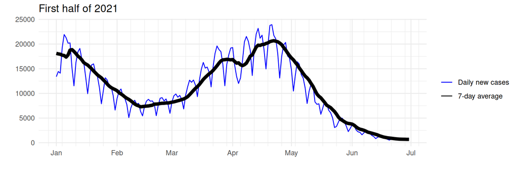

## German Trend

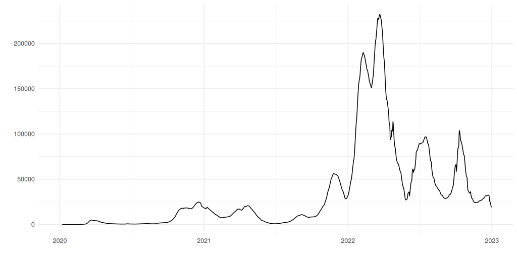

## German Trend - Summer Period

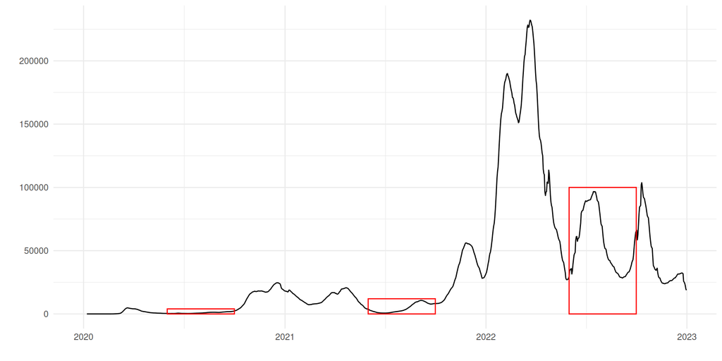

## School summer vacations

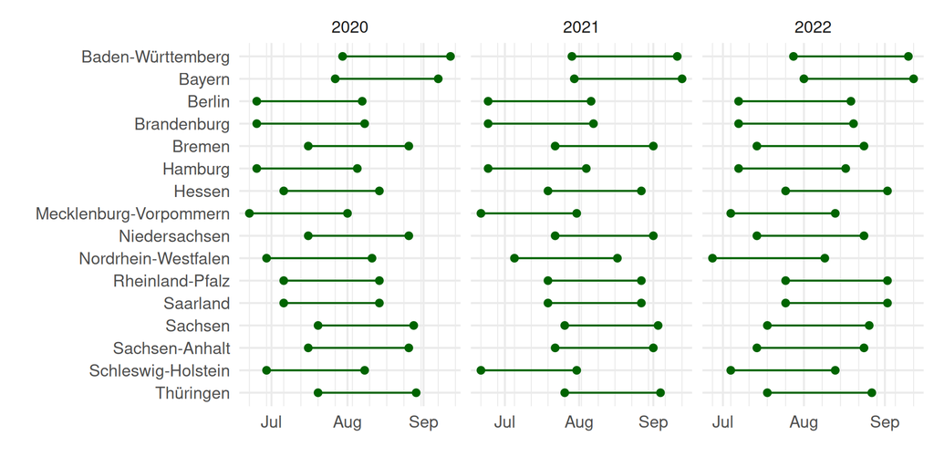

## German Trend with Summer Breaks

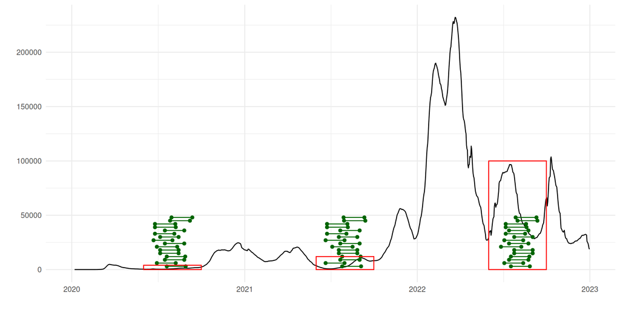

**Strategy of analysis:**  
Compare Trend in federal state during summer break with the German-wide trend.

## Idea

- Five days delay (incubation period)
- Re-scale the German-wide trend
- Measure the **summerbreak effect** 5 days after the end of the summer break

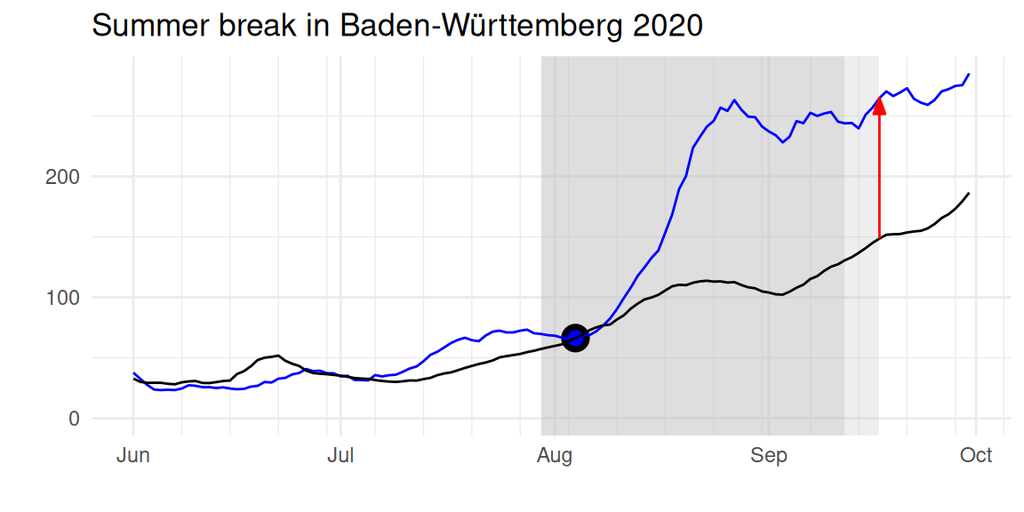

- Cases increase more than the German-wide trend.

## Two years later

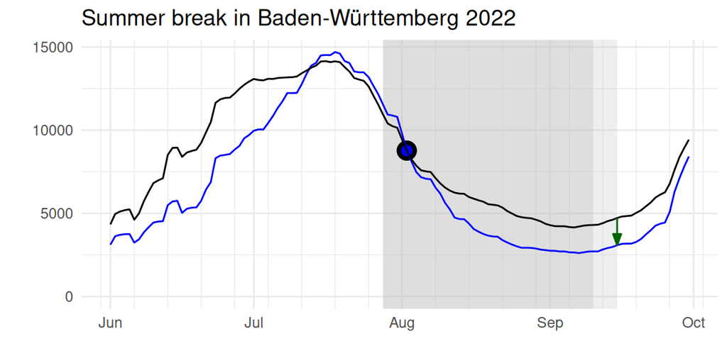

- Cases increase less than the German-wide trend.

## All federal states in 2020

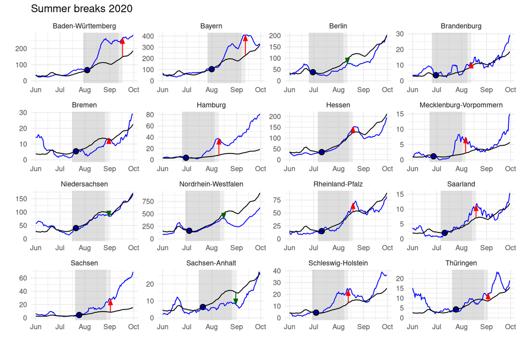

## Vacation more often increase cases

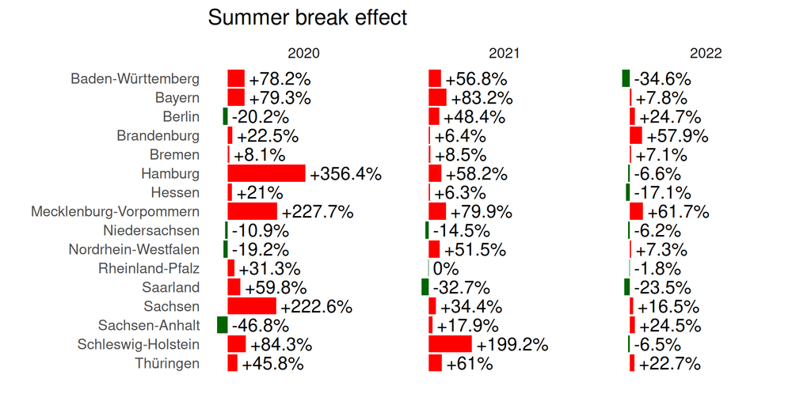

- In most federal states case number increased more than the German-wide trend
- The relationsships vanishes in 2022 (transition to endemic phase)

## Average summer break effect

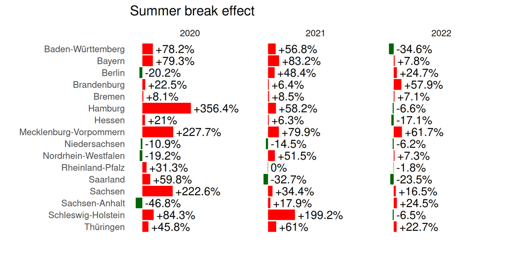

| 2020 | 2021 | 2022 |
| --- | --- | --- |
| +46% | +33.3% | +5.45% |

## Significance of average effect

| Year | Mean effect | Lower bound 0.95-CI | p-value |
| --- | --- | --- | --- |
| 2020 | +46% | +13.7% | 0.00899 |
| 2021 | +33.3% | +14.2% | 0.00266 |
| 2022 | +5.45% | -5.13% | 0.196 |

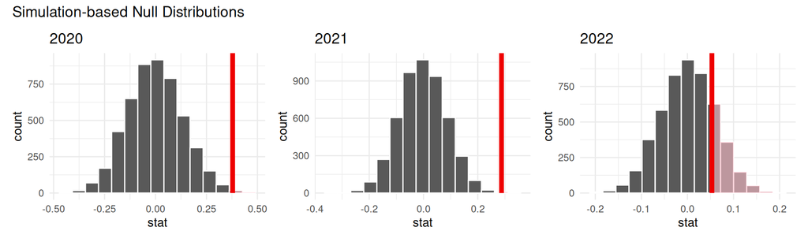

Bootstrapped null distributions for the samples of the log-transformed effect for 2020, 2021, and 2022. For each sample there are 16 values (one per federal state). The null hypothesis is that the mean of these 16 values is zero. The red line shows the point estimate of the observed means.

## Conclusion: **Increasing** is stronger

☀️️ Summer break

**Decreasing**

➡️ kids are not in school ➡️ parents take holidays ➡️ cuts off channels of contagion

**Increasing**

➡️ families travel ➡️ meeting relatives and friends ➡️ new channels of contagion

Potential reason:  
**Prevention measures**  
at **school** and the at the **workplace** worked better than  
those for **leisure** activities or when meeting **friends and relatives**.

# Appendix: Additional analyses

## All federal states in 2021

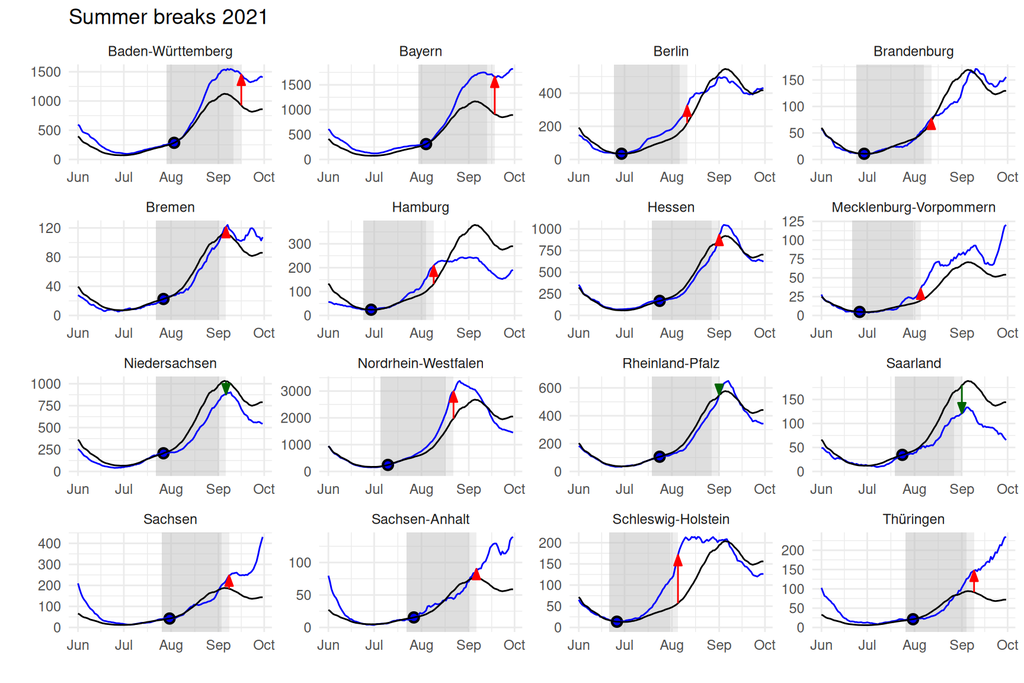

## All federal states in 2022

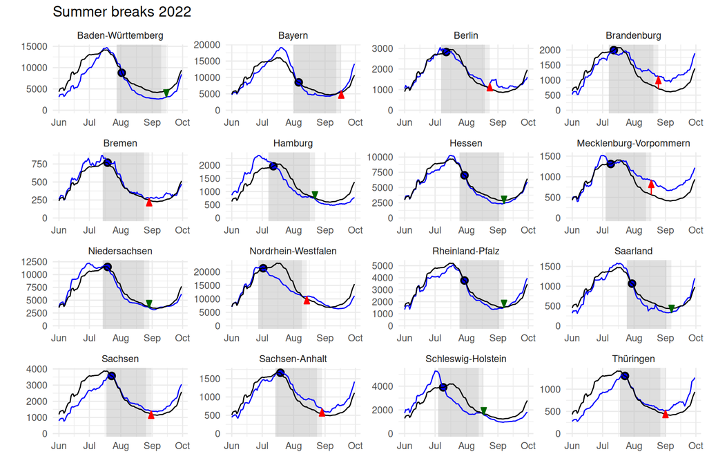

## No geographic pattern

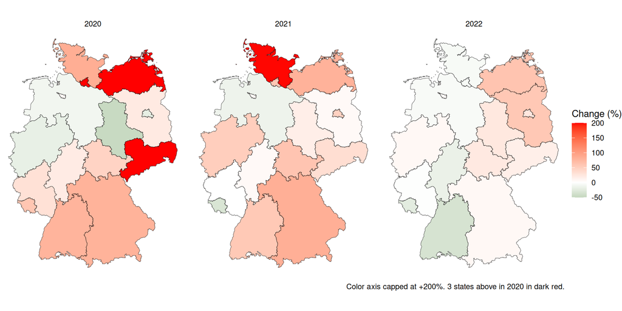